# Longboard Project

Aaryan Jha

2023-05-14

Longboarding is a popular sport that combines the excitment of speed with the skill of balance and control. As with any physical activity, there are many factors that can affect performance, and one of the most important metrics for longboarders is speed maintianed throughout the journey. Understanding how different variables impact average speed can help riders optimize their performance and improve their overall experience.

In this project, I aim to explore the relationship between average speed and various factors such as distance, heart rate, temperature, and equipment type. By analyzing data collected from longboarders, I hope to identify the key factors that affect average speed and provide recommendations for how riders can optimize their performance.

```r
library(tidyverse)
library(leaps)
library(ISLR)
library(psych)
library(MASS)
library(glmnet)
library(caret)
library(fastDummies)
library(mlr3)
library(forcats)
library(dplyr)
```

```r
data_link = "/Users/aaryanjha/Desktop/Longboard_Project/longboard_train_data_reduced.csv"
df = read.table(data_link, sep = ",", header = TRUE)
vars = c("Avg_Speed", "Distance", "Avg_HR",  "Ascent_Ratio", "Wind_Speed2", "Wheel_Diameter", "Wheel_Durometer", "log_exp", "Max_HR", "Total_Ascent", "Board", "Board_Type", "City_State", "Route")
preprocess <- function(df){
    pro_df <- df
    day_one <- strptime("3/13/21 00:00", format = "%m/%d/%y %H:%M")
    pro_df$Date <- strptime(pro_df$Date, format = "%m/%d/%y %H:%M")
    pro_df$Experience <- as.numeric(difftime(pro_df$Date, day_one, units = "days"))
    pro_df$log_exp <- log(pro_df$Experience)
    pro_df$Ascent_Ratio <- pro_df$Total_Ascent / pro_df$Distance
    pro_df$Wind_Speed2 <- pro_df$Wind_Speed^2
    pro_df$Avg_Speed <- log(pro_df$Avg_Speed)

    pro_df$Route <- as.integer(forcats::fct_inorder(pro_df$Route))

    categorical_columns <- c("Board", "Board_Type", "City_State")
    for (col in categorical_columns) {
      one_hot <- model.matrix(~ 0 + ., data = pro_df[, col, drop = FALSE])
      colnames(one_hot) <- gsub("^[^_]*_", paste0(col, "_"), colnames(one_hot))
      pro_df <- cbind(pro_df, one_hot)
    }
    pro_df <- pro_df[, !names(pro_df) %in% categorical_columns]

    vars <- c("Avg_Speed", "Distance", "Avg_HR", "Ascent_Ratio", "Wind_Speed2", "Wheel_Diameter", "Wheel_Durometer", "log_exp", "Max_HR", "Total_Ascent", "Route", grep("Board_", names(pro_df), value = TRUE), grep("Board_Type_", names(pro_df), value = TRUE), grep("City_State_", names(pro_df), value = TRUE))
    pro_df <- subset(pro_df, select = vars)
    return(pro_df)
}
pro_df <- preprocess(df)
```

The Data is first collected and pre-processed. The preprocessing involves creating new variables, encoding categorical variables using one-hot encoding, and removing unnecessary variables. The preparation of data is an important step to ensure the efficiency for further modeling and analysis.

```r
pro_df1 <- pro_df
if (any(is.na(pro_df1))) {
  pro_df1 <- na.omit(pro_df1)
}
if (any(is.infinite(as.matrix(pro_df1)))){
  pro_df1 <- pro_df1[!apply(pro_df1, 1, function(x) any(is.infinite(as.matrix(x)))),]
}
lin_mod1 = lm(Avg_Speed ~ ., data = pro_df1)
summary(lin_mod1)
```

```
##
## Call:
## lm(formula = Avg_Speed ~ ., data = pro_df1)
##
## Residuals:
##      Min       1Q   Median       3Q      Max
## -0.56861 -0.03547  0.00895  0.07068  0.20989
##
## Coefficients: (6 not defined because of singularities)
##                                     Estimate Std. Error t value Pr(>|t|)
## (Intercept)                        3.1356365  6.0457443   0.519  0.60557
## Distance                           0.0429903  0.0211628   2.031  0.04585 *
## Avg_HR                             0.0071639  0.0026961   2.657  0.00967 **
## Ascent_Ratio                       0.0046724  0.0060376   0.774  0.44150
## Wind_Speed2                       -0.0001262  0.0002266  -0.557  0.57928
## Wheel_Diameter                    -0.0097518  0.0147186  -0.663  0.50970
## Wheel_Durometer                   -0.0251638  0.0614228  -0.410  0.68324
## log_exp                            0.0936319  0.0313691   2.985  0.00386 **
## Max_HR                             0.0013099  0.0026932   0.486  0.62816
## Total_Ascent                      -0.0006780  0.0006885  -0.985  0.32799
## Route                             -0.0223645  0.0275827  -0.811  0.42011
## Board_Type_Type                    0.0183973  0.1333820   0.138  0.89068
## `Board_Type_TypeDrop Through`      0.0652627  0.1849070   0.353  0.72514
## Board_Type_TypePlatform            0.0877022  0.1280356   0.685  0.49552
## `Board_Type_TypeTop Mount`                NA         NA      NA       NA
## Board_Type_Type.1                         NA         NA      NA       NA
## `Board_Type_TypeDrop Through.1`           NA         NA      NA       NA
## Board_Type_TypePlatform.1                 NA         NA      NA       NA
## `Board_Type_TypeTop Mount.1`              NA         NA      NA       NA
## `City_State_StateGreencastle, IN`  0.2740825  0.2514711   1.090  0.27933
## `City_State_StateRipon, WI`               NA         NA      NA       NA
## ---
## Signif. codes:  0 '***' 0.001 '**' 0.01 '*' 0.05 '.' 0.1 ' ' 1
##
## Residual standard error: 0.1264 on 73 degrees of freedom
## Multiple R-squared:  0.6947, Adjusted R-squared:  0.6362
## F-statistic: 11.87 on 14 and 73 DF,  p-value: 1.06e-13
```

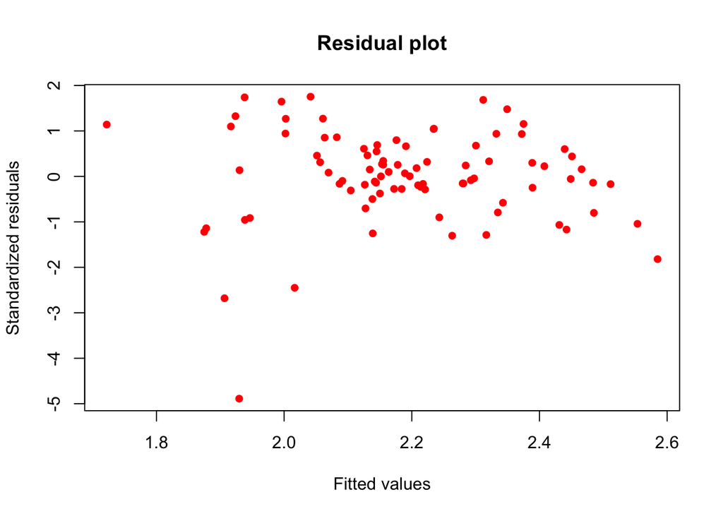

```r
plot(fitted(lin_mod1), rstandard(lin_mod1), col = "red", pch = 16,
     xlab = "Fitted values", ylab = "Standardized residuals", main = "Residual plot")
```

First, we just create a simple linear model. The model has a residual standard error of 0.1264, indicating that the average difference between the predicted values and the actual values is relatively small. The multiple R-squared value of 0.6947 indicates that the model explains a significant amount of the variability in the response variable. The adjusted R-squared value of 0.6362 takes into account the number of predictor variables in the model and suggests that the model is still a good fit even after accounting for the complexity of the model. A p-value of 1.06e-13 indicates that the model is statistically significant and that at least one of the predictor variables is significantly associated with the response variable.

```r
#Box-Cox transformation
pre_proc <- preProcess(pro_df1, method = "BoxCox")
pro_df_bc <- predict(pre_proc, pro_df1)
new_model1 <- lm(Avg_Speed ~ ., data = pro_df_bc)
summary(new_model1)
```

```
##
## Call:
## lm(formula = Avg_Speed ~ ., data = pro_df_bc)
##
## Residuals:
##     Min      1Q  Median      3Q     Max
## -0.8766 -0.1090  0.0096  0.1353  0.4686
##
## Coefficients: (6 not defined because of singularities)
##                                     Estimate Std. Error t value Pr(>|t|)
## (Intercept)                        8.153e+03  1.024e+04   0.796 0.428600
## Distance                           6.618e-02  2.496e-02   2.651 0.009823 **
## Avg_HR                             5.364e-03  1.918e-03   2.796 0.006608 **
## Ascent_Ratio                       1.690e-01  1.235e-01   1.368 0.175471
## Wind_Speed2                       -2.767e-04  4.289e-04  -0.645 0.520878
## Wheel_Diameter                    -1.631e+04  2.048e+04  -0.796 0.428425
## Wheel_Durometer                   -5.662e-04  1.324e-03  -0.428 0.670267
## log_exp                            1.969e-01  5.706e-02   3.451 0.000932 ***
## Max_HR                             2.586e-05  3.339e-05   0.775 0.441127
## Total_Ascent                      -2.797e-02  1.769e-02  -1.581 0.118200
## Route                             -2.202e-01  9.400e-02  -2.343 0.021864 *
## Board_Type_Type                    1.369e-01  3.220e-01   0.425 0.671869
## `Board_Type_TypeDrop Through`      2.219e-01  4.025e-01   0.551 0.583158
## Board_Type_TypePlatform            3.016e-01  3.137e-01   0.961 0.339505
## `Board_Type_TypeTop Mount`                NA         NA      NA       NA
## Board_Type_Type.1                         NA         NA      NA       NA
## `Board_Type_TypeDrop Through.1`           NA         NA      NA       NA
## Board_Type_TypePlatform.1                 NA         NA      NA       NA
## `Board_Type_TypeTop Mount.1`              NA         NA      NA       NA
## `City_State_StateGreencastle, IN`  8.151e-01  3.508e-01   2.323 0.022951 *
## `City_State_StateRipon, WI`               NA         NA      NA       NA
## ---
## Signif. codes:  0 '***' 0.001 '**' 0.01 '*' 0.05 '.' 0.1 ' ' 1
##
## Residual standard error: 0.2385 on 73 degrees of freedom
## Multiple R-squared:  0.7503, Adjusted R-squared:  0.7024
## F-statistic: 15.67 on 14 and 73 DF,  p-value: < 2.2e-16
```

```r
#Square root transformation
pro_df_sqrt <- pro_df1
pro_df_sqrt$Avg_Speed <- sqrt(pro_df_sqrt$Avg_Speed)
new_model_sqrt <- lm(Avg_Speed ~ ., data = pro_df_sqrt)
summary(new_model_sqrt)
```

```
##
## Call:
## lm(formula = Avg_Speed ~ ., data = pro_df_sqrt)
##
## Residuals:
##       Min        1Q    Median        3Q       Max
## -0.218974 -0.010897  0.004543  0.023808  0.071604
##
## Coefficients: (6 not defined because of singularities)
##                                     Estimate Std. Error t value Pr(>|t|)
## (Intercept)                        1.676e+00  2.187e+00   0.766  0.44607
## Distance                           1.562e-02  7.656e-03   2.041  0.04491 *
## Avg_HR                             2.547e-03  9.753e-04   2.611  0.01095 *
## Ascent_Ratio                       1.516e-03  2.184e-03   0.694  0.48980
## Wind_Speed2                       -3.683e-05  8.196e-05  -0.449  0.65449
## Wheel_Diameter                    -3.131e-03  5.324e-03  -0.588  0.55832
## Wheel_Durometer                   -7.265e-03  2.222e-02  -0.327  0.74463
## log_exp                            3.174e-02  1.135e-02   2.797  0.00658 **
## Max_HR                             3.984e-04  9.743e-04   0.409  0.68382
## Total_Ascent                      -2.294e-04  2.491e-04  -0.921  0.36003
## Route                             -9.101e-03  9.978e-03  -0.912  0.36474
## Board_Type_Type                    3.644e-03  4.825e-02   0.076  0.94000
## `Board_Type_TypeDrop Through`      1.583e-02  6.689e-02   0.237  0.81362
## Board_Type_TypePlatform            2.811e-02  4.632e-02   0.607  0.54573
## `Board_Type_TypeTop Mount`                NA         NA      NA       NA
## Board_Type_Type.1                         NA         NA      NA       NA
## `Board_Type_TypeDrop Through.1`           NA         NA      NA       NA
## Board_Type_TypePlatform.1                 NA         NA      NA       NA
## `Board_Type_TypeTop Mount.1`              NA         NA      NA       NA
## `City_State_StateGreencastle, IN`  1.072e-01  9.097e-02   1.179  0.24224
## `City_State_StateRipon, WI`               NA         NA      NA       NA
## ---
## Signif. codes:  0 '***' 0.001 '**' 0.01 '*' 0.05 '.' 0.1 ' ' 1
##
## Residual standard error: 0.04573 on 73 degrees of freedom
## Multiple R-squared:  0.6728, Adjusted R-squared:  0.6101
## F-statistic: 10.72 on 14 and 73 DF,  p-value: 1.108e-12
```

```r
#Power transformation
pro_df_pow <- pro_df1
pro_df_pow$Avg_Speed <- pro_df_pow$Avg_Speed^2
new_model_pow <- lm(Avg_Speed ~ ., data = pro_df_pow)
summary(new_model_pow)
```

```
##
## Call:
## lm(formula = Avg_Speed ~ ., data = pro_df_pow)
##
## Residuals:
##     Min      1Q  Median      3Q     Max
## -1.9365 -0.1922  0.0129  0.2879  0.9053
##
## Coefficients: (6 not defined because of singularities)
##                                     Estimate Std. Error t value Pr(>|t|)
## (Intercept)                       11.8760438 23.7521513   0.500  0.61858
## Distance                           0.1629530  0.0831431   1.960  0.05382 .
## Avg_HR                             0.0286713  0.0105921   2.707  0.00845 **
## Ascent_Ratio                       0.0217458  0.0237202   0.917  0.36229
## Wind_Speed2                       -0.0006708  0.0008902  -0.754  0.45356
## Wheel_Diameter                    -0.0470098  0.0578255  -0.813  0.41888
## Wheel_Durometer                   -0.1397780  0.2413140  -0.579  0.56421
## log_exp                            0.4093551  0.1232409   3.322  0.00140 **
## Max_HR                             0.0067682  0.0105810   0.640  0.52440
## Total_Ascent                      -0.0029458  0.0027049  -1.089  0.27970
## Route                             -0.0617601  0.1083653  -0.570  0.57048
## Board_Type_Type                    0.1402290  0.5240230   0.268  0.78976
## `Board_Type_TypeDrop Through`      0.4467729  0.7264514   0.615  0.54046
## Board_Type_TypePlatform            0.4267409  0.5030184   0.848  0.39901
## `Board_Type_TypeTop Mount`                NA         NA      NA       NA
## Board_Type_Type.1                         NA         NA      NA       NA
## `Board_Type_TypeDrop Through.1`           NA         NA      NA       NA
## Board_Type_TypePlatform.1                 NA         NA      NA       NA
## `Board_Type_TypeTop Mount.1`              NA         NA      NA       NA
## `City_State_StateGreencastle, IN`  0.8707122  0.9879645   0.881  0.38104
## `City_State_StateRipon, WI`               NA         NA      NA       NA
## ---
## Signif. codes:  0 '***' 0.001 '**' 0.01 '*' 0.05 '.' 0.1 ' ' 1
##
## Residual standard error: 0.4967 on 73 degrees of freedom
## Multiple R-squared:  0.7293, Adjusted R-squared:  0.6774
## F-statistic: 14.05 on 14 and 73 DF,  p-value: 1.736e-15
```

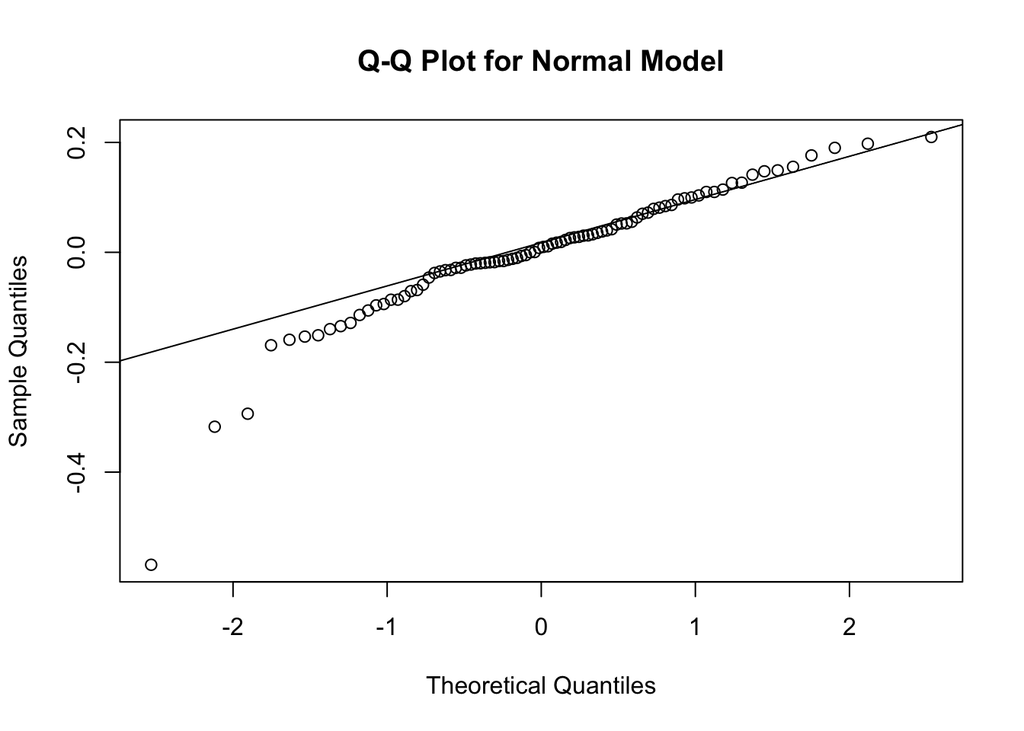

```r
#Q-Q plot for normal model
qqnorm(lin_mod1$residuals, main = "Q-Q Plot for Normal Model", xlab = "Theoretical Quantiles", ylab = "Sample Quantiles")
qqline(lin_mod1$residuals)
```

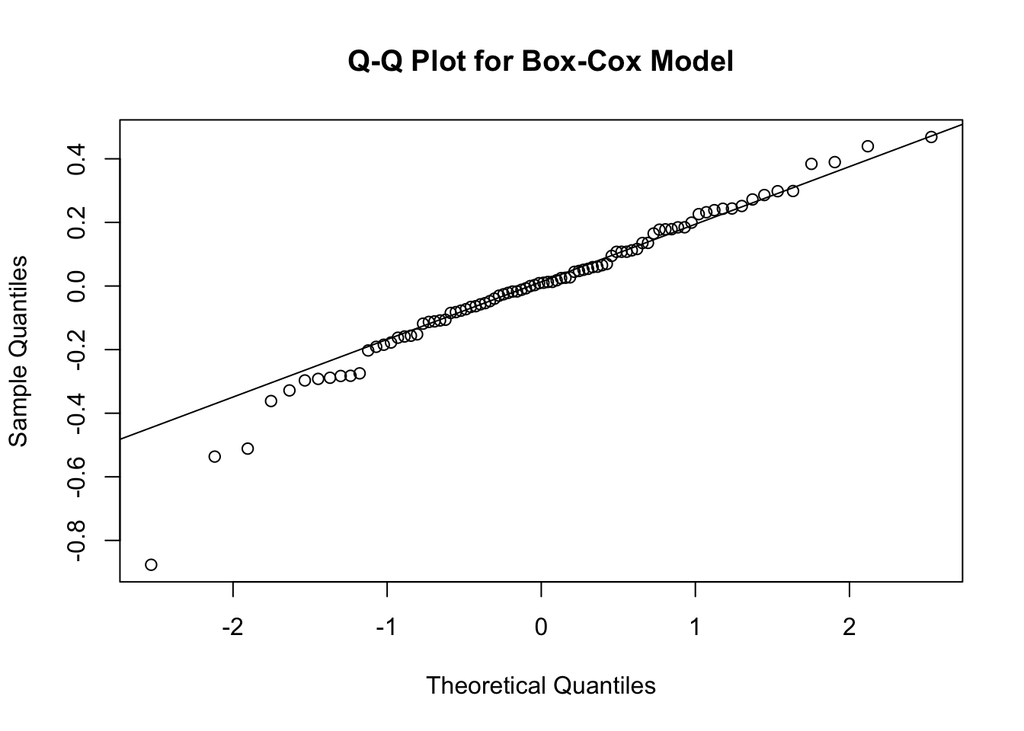

```r
#Q-Q plot for Box-Cox model
qqnorm(new_model1$residuals, main = "Q-Q Plot for Box-Cox Model", xlab = "Theoretical Quantiles", ylab = "Sample Quantiles")
qqline(new_model1$residuals)
```

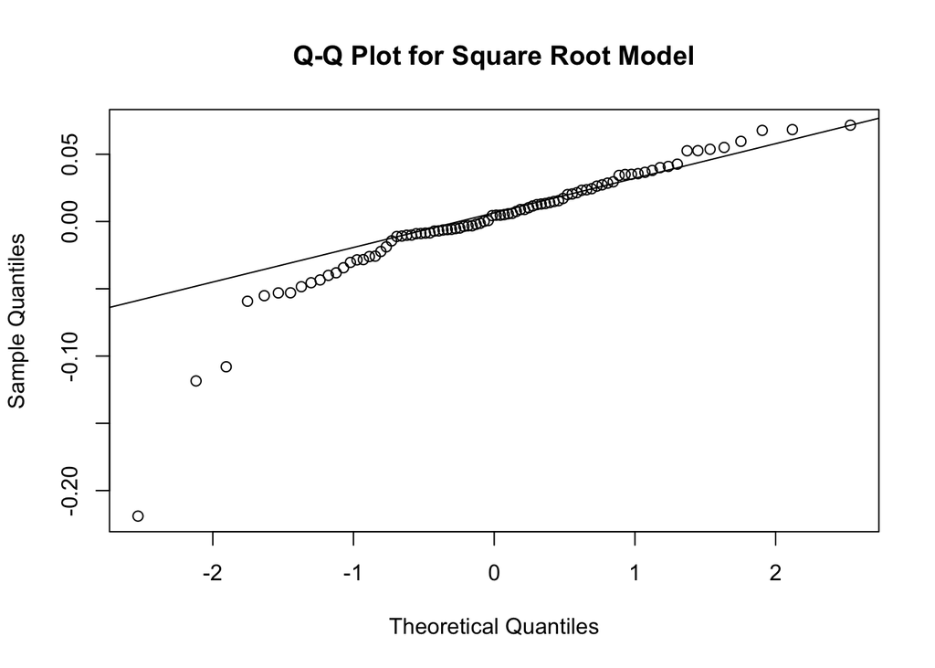

```r
#Q-Q plot for Square Root model
qqnorm(new_model_sqrt$residuals, main = "Q-Q Plot for Square Root Model", xlab = "Theoretical Quantiles", ylab = "Sample Quantiles")
qqline(new_model_sqrt$residuals)
```

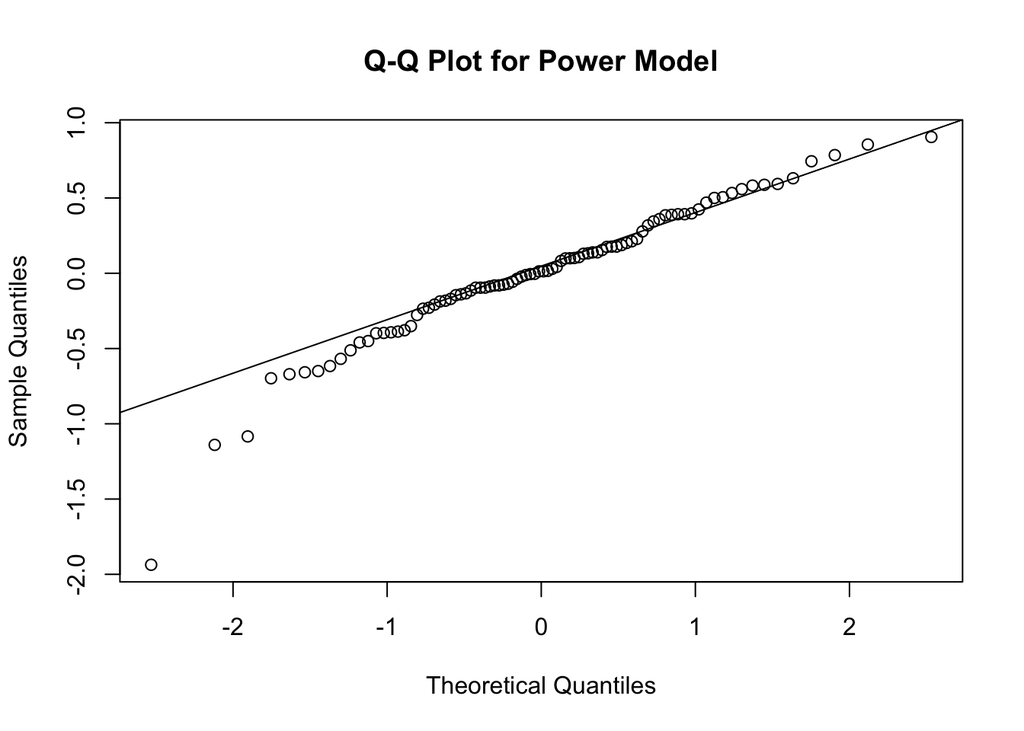

```r
#Q-Q plot for Power model
qqnorm(new_model_pow$residuals, main = "Q-Q Plot for Power Model", xlab = "Theoretical Quantiles", ylab = "Sample Quantiles")
qqline(new_model_pow$residuals)
```

Q-Q plots are used to evaluate how well a model’s residuals fit a normal distribution. For each plot, the theoretical quantiles are plotted against the sample quantiles. A good model should have residuals that closely follow a straight line on the plot which after the different transformations, the Box-Cox method seems to have a cleanest straigth line.

```r
pro_dfNoNa <- na.exclude(pro_df)
model_BIC <- MASS:: stepAIC(lm(Avg_Speed ~., data = pro_dfNoNa), m = log(nrow(pro_dfNoNa)), trace = 0)

#New model with non-equipment factors
lin_model = lm(df$Avg_Speed ~ pro_df$Wind_Speed + pro_df$Wheel_Diameter + pro_df$Wheel_Durometer + df$Board_Type + df$Temp +df$Relative_Humidity + df$Route + pro_df$log_exp, data = pro_dfNoNa)
summary(lin_model)
```

```
##
## Call:
## lm(formula = df$Avg_Speed ~ pro_df$Wind_Speed + pro_df$Wheel_Diameter +
##     pro_df$Wheel_Durometer + df$Board_Type + df$Temp + df$Relative_Humidity +
##     df$Route + pro_df$log_exp, data = pro_dfNoNa)
##
## Residuals:
##     Min      1Q  Median      3Q     Max
## -2.3902 -0.5430  0.1075  0.5036  1.7034
##
## Coefficients:
##                               Estimate Std. Error t value Pr(>|t|)
## (Intercept)                  48.438634  43.072542   1.125   0.2645
## pro_df$Wind_Speed             0.001887   0.001640   1.151   0.2535
## pro_df$Wheel_Diameter        -0.106486   0.099526  -1.070   0.2882
## pro_df$Wheel_Durometer       -0.433751   0.444461  -0.976   0.3323
## df$Board_TypeDrop Through     0.064099   1.031025   0.062   0.9506
## df$Board_TypePlatform         0.744228   0.297485   2.502   0.0146 *
## df$Board_TypeTop Mount       -0.681296   0.865628  -0.787   0.4338
## df$Temp                      -0.005956   0.009609  -0.620   0.5373
## df$Relative_Humidity          0.001659   0.005883   0.282   0.7787
## df$Routelimedale              1.948869   0.438949   4.440 3.14e-05 ***
## df$Routeradio_road_to_carter  0.433089   1.081365   0.401   0.6900
## df$Routeradio_road_to_K       0.260383   1.067465   0.244   0.8080
## df$Routeripon_in_town        -2.469524   1.139564  -2.167   0.0335 *
## df$Routeripon_west_loop       1.006502   1.026247   0.981   0.3300
## pro_df$log_exp                0.603392   0.234329   2.575   0.0121 *
## ---
## Signif. codes:  0 '***' 0.001 '**' 0.01 '*' 0.05 '.' 0.1 ' ' 1
##
## Residual standard error: 0.8462 on 73 degrees of freedom
##   (133 observations deleted due to missingness)
## Multiple R-squared:  0.8044, Adjusted R-squared:  0.7669
## F-statistic: 21.44 on 14 and 73 DF,  p-value: < 2.2e-16
```

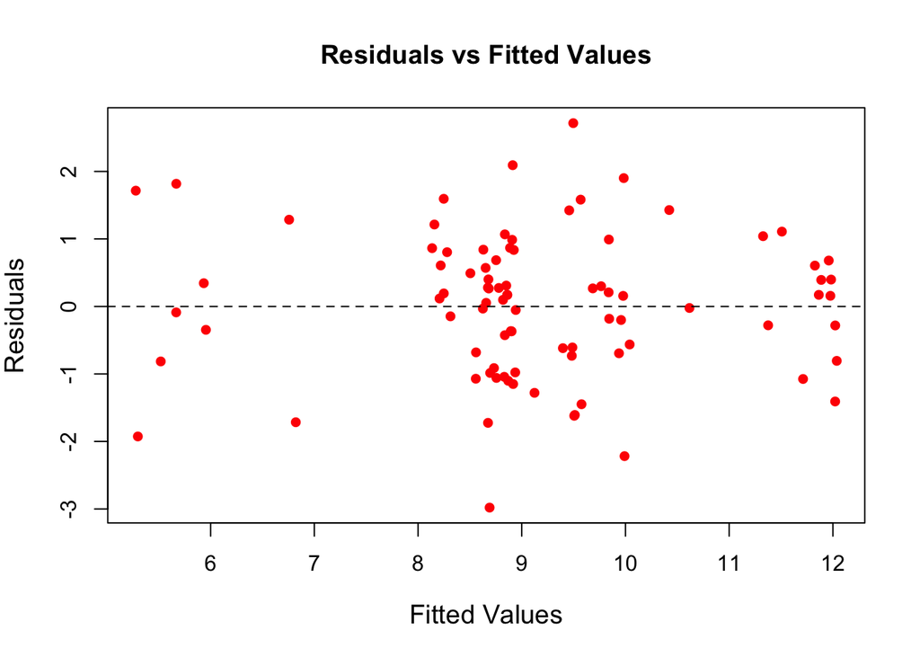

```r
plot(fitted(lin_model), rstandard(lin_model), col = "red", pch = 16,
     main = "Residuals vs Fitted Values", xlab = "Fitted Values", ylab = "Residuals",
     cex.main = 1.2, cex.lab = 1.2)
abline(h = 0, lty = 2)
```

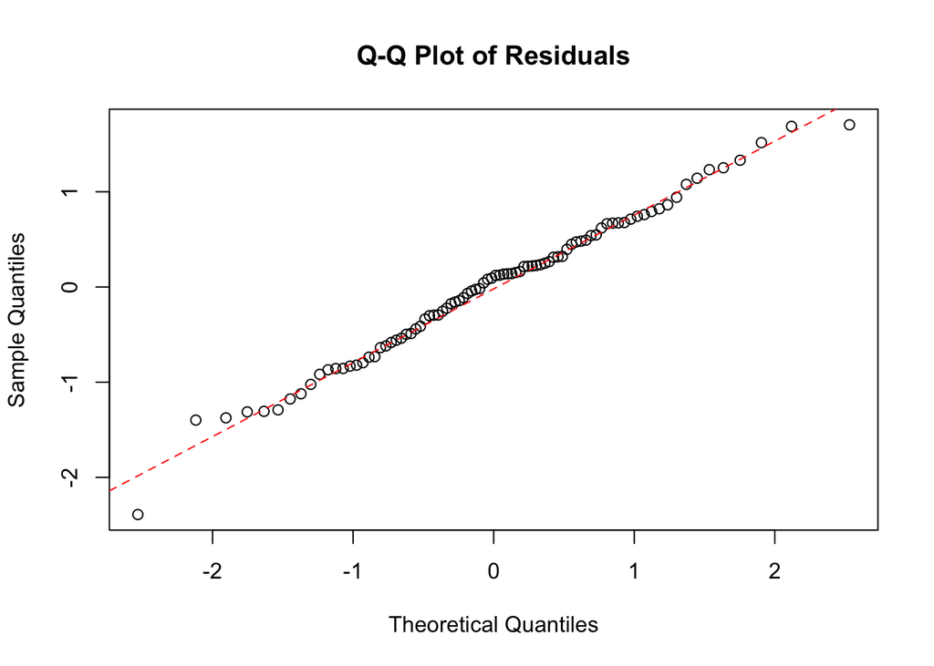

```r
qqnorm(lin_model$residuals, main = "Q-Q Plot of Residuals", xlab = "Theoretical Quantiles", ylab = "Sample Quantiles")
qqline(lin_model$residuals, col = "red", lty = 2)
```

```r
confint(lin_model, level = 0.95)
```

```
##                                      2.5 %        97.5 %
## (Intercept)                  -37.404817999 134.282086075
## pro_df$Wind_Speed             -0.001380706   0.005154788
## pro_df$Wheel_Diameter         -0.304840544   0.091867750
## pro_df$Wheel_Durometer        -1.319561723   0.452058971
## df$Board_TypeDrop Through     -1.990731895   2.118929502
## df$Board_TypePlatform          0.151341317   1.337115659
## df$Board_TypeTop Mount        -2.406490364   1.043898570
## df$Temp                       -0.025107892   0.013194912
## df$Relative_Humidity          -0.010064810   0.013383378
## df$Routelimedale               1.074045501   2.823692211
## df$Routeradio_road_to_carter  -1.722068054   2.588247017
## df$Routeradio_road_to_K       -1.867072118   2.387838756
## df$Routeripon_in_town         -4.740670568  -0.198376658
## df$Routeripon_west_loop       -1.038804542   3.051809012
## pro_df$log_exp                 0.136374294   1.070410002
```

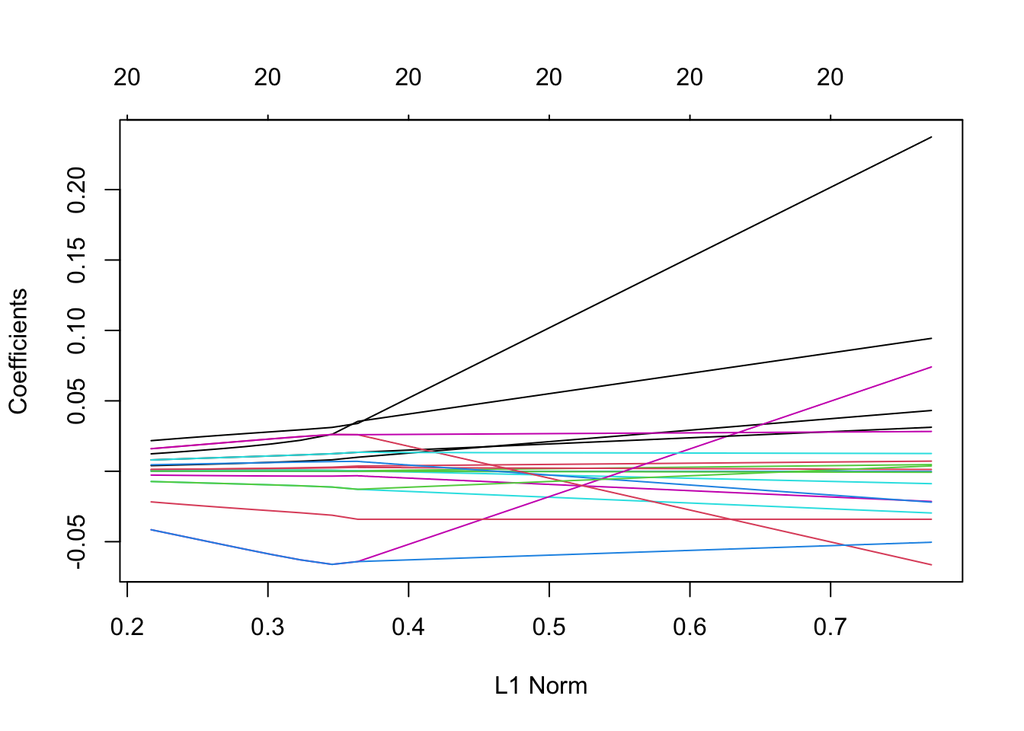

```r
model_ridge <- glmnet(x = as.matrix(pro_df1[, -1]), y = pro_df1$Avg_Speed, alpha = 0, lambda = seq(0, 1, by = 0.1))
plot(model_ridge)
```

```r
summary(model_ridge)
```

```
##           Length Class     Mode
## a0         11    -none-    numeric
## beta      220    dgCMatrix S4
## df         11    -none-    numeric
## dim         2    -none-    numeric
## lambda     11    -none-    numeric
## dev.ratio  11    -none-    numeric
## nulldev     1    -none-    numeric
## npasses     1    -none-    numeric
## jerr        1    -none-    numeric
## offset      1    -none-    logical
## call        5    -none-    call
## nobs        1    -none-    numeric
```

The coefficients for Wind_Speed, Temp, Wheel_Diameter, Wheel_Durometer, $Board_TypeDrop Through, Board_TypeTop Mount, Relative_Humidity, Routeradio_road_to_carter, Routeradio_road_to_K, and Routeripon_west_loop include zero in their intervals, suggesting that their effects on the response variable may not be significant. Based on the provided confidence intervals, there is limited evidence to support significant relationships between most predictor variables and the dependent variable.

```r
model_cv <- cv.glmnet(x = as.matrix(pro_df1[, -1]), y = pro_df1$Avg_Speed, alpha = 0)
lambda_opt <- model_cv$lambda.min
model_final <- glmnet(x = as.matrix(pro_df1[, -1]), y = pro_df1$Avg_Speed, alpha = 0, lambda = lambda_opt)
coef(model_final)
```

```
## 21 x 1 sparse Matrix of class "dgCMatrix"
##                                            s0
## (Intercept)                      1.143818e+00
## Distance                         1.105165e-02
## Avg_HR                           4.165087e-03
## Ascent_Ratio                     2.342316e-04
## Wind_Speed2                     -1.157121e-04
## Wheel_Diameter                   1.598947e-04
## Wheel_Durometer                 -2.849638e-03
## log_exp                          4.222107e-02
## Max_HR                           2.834673e-03
## Total_Ascent                     3.130298e-05
## Route                            6.890018e-03
## Board_Type_Type                 -1.390295e-02
## Board_Type_TypeDrop Through     -5.829745e-02
## Board_Type_TypePlatform          1.397116e-02
## Board_Type_TypeTop Mount         2.406353e-02
## Board_Type_Type.1               -1.384918e-02
## Board_Type_TypeDrop Through.1   -5.831619e-02
## Board_Type_TypePlatform.1        1.387661e-02
## Board_Type_TypeTop Mount.1       2.414740e-02
## City_State_StateGreencastle, IN  3.573234e-02
## City_State_StateRipon, WI       -3.570397e-02
```

```r
pca_df <- princomp(pro_df1, fix_sign = TRUE)
summary(pca_df)
```

```
## Importance of components:
##                             Comp.1     Comp.2       Comp.3       Comp.4
## Standard deviation     117.5742142 63.3455485 12.738786546 12.226936513
## Proportion of Variance   0.7597119  0.2205245  0.008918275  0.008215993
## Cumulative Proportion    0.7597119  0.9802364  0.989154684  0.997370677
##                             Comp.5       Comp.6       Comp.7       Comp.8
## Standard deviation     5.301208277 4.0851553467 1.254163e+00 6.983591e-01
## Proportion of Variance 0.001544452 0.0009171532 8.644355e-05 2.680293e-05
## Cumulative Proportion  0.998915129 0.9998322825 9.999187e-01 9.999455e-01
##                              Comp.9      Comp.10      Comp.11      Comp.12
## Standard deviation     6.544330e-01 6.030049e-01 3.682827e-01 0.1562774155
## Proportion of Variance 2.353721e-05 1.998327e-05 7.453964e-06 0.0000013422
## Cumulative Proportion  9.999691e-01 9.999890e-01 9.999965e-01 0.9999978456
##                             Comp.13      Comp.14      Comp.15      Comp.16
## Standard deviation     1.426501e-01 1.157006e-01 7.392840e-02 1.894010e-09
## Proportion of Variance 1.118327e-06 7.356914e-07 3.003636e-07 1.971466e-22
## Cumulative Proportion  9.999990e-01 9.999997e-01 1.000000e+00 1.000000e+00
##                        Comp.17 Comp.18 Comp.19 Comp.20 Comp.21
## Standard deviation           0       0       0       0       0
## Proportion of Variance       0       0       0       0       0
## Cumulative Proportion        1       1       1       1       1
```

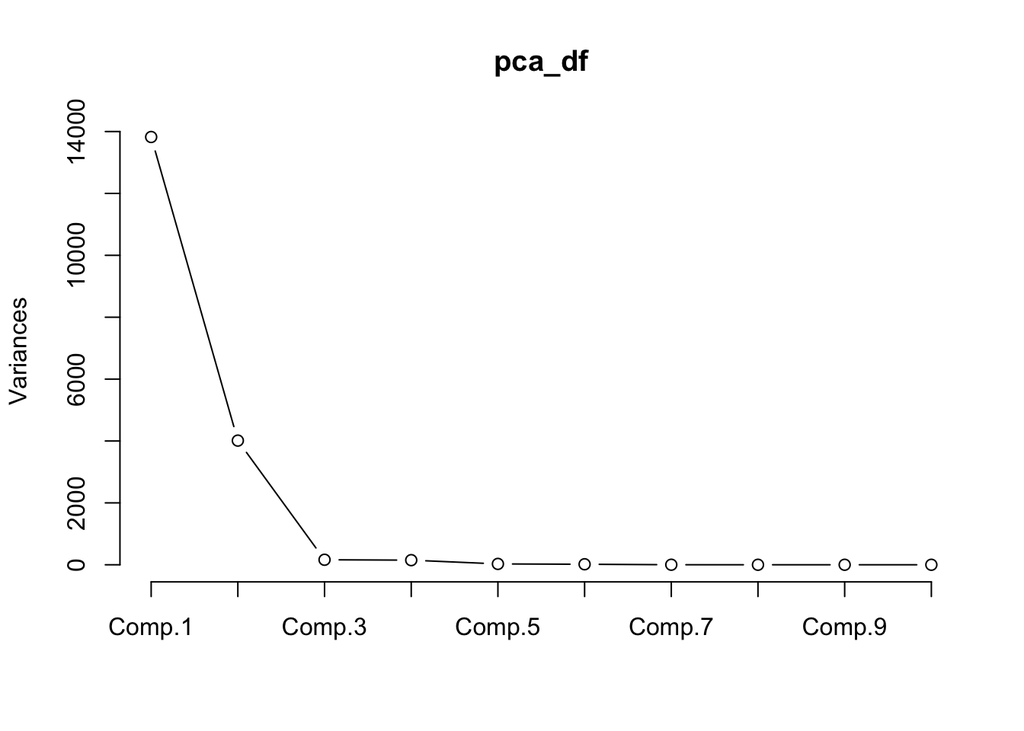

```r
plot(pca_df, type = "l")
```

Here, the principal component analysis (PCA) is performed. We can see which variables have the most influence on each principal component, as well as the amount of variance explained by each component. This information can be used to identify patterns and relationships in the data, as well as to reduce the dimensionality of the dataset for further analysis.

```r
n <- nrow(pro_df1)
eig <- eigen(cov(pro_df1) * (n - 1) / n)
A <- eig$vectors
pca_df$sdev^2 - eig$values
```

```
##        Comp.1        Comp.2        Comp.3        Comp.4        Comp.5
##  0.000000e+00 -1.364242e-12  8.526513e-14 -2.842171e-14 -1.136868e-13
##        Comp.6        Comp.7        Comp.8        Comp.9       Comp.10
##  4.263256e-14 -3.774758e-15  1.665335e-15  2.553513e-15 -7.938095e-15
##       Comp.11       Comp.12       Comp.13       Comp.14       Comp.15
##  1.276756e-15  3.236994e-15  2.185752e-16 -8.326673e-17 -5.551115e-17
##       Comp.16       Comp.17       Comp.18       Comp.19       Comp.20
## -2.705050e-19  4.963369e-18  9.639639e-18  3.912046e-17  3.921757e-17
##       Comp.21
##  4.058733e-17
```

```r
pca_df$loadings
```

```
##
## Loadings:
##                                 Comp.1 Comp.2 Comp.3 Comp.4 Comp.5 Comp.6
## Avg_Speed
## Distance                                                     0.212
## Avg_HR                                                0.708        -0.698
## Ascent_Ratio                                   0.222        -0.941 -0.101
## Wind_Speed2                             0.999
## Wheel_Diameter                                 0.898 -0.177  0.241 -0.131
## Wheel_Durometer                               -0.236
## log_exp
## Max_HR                                         0.229  0.678         0.688
## Total_Ascent                     0.994
## Route                                          0.159
## Board_Type_Type
## Board_Type_TypeDrop Through
## Board_Type_TypePlatform
## Board_Type_TypeTop Mount
## Board_Type_Type.1
## Board_Type_TypeDrop Through.1
## Board_Type_TypePlatform.1
## Board_Type_TypeTop Mount.1
## City_State_StateGreencastle, IN
## City_State_StateRipon, WI
##                                 Comp.7 Comp.8 Comp.9 Comp.10 Comp.11 Comp.12
## Avg_Speed
## Distance                         0.214        -0.646  0.680   0.100
## Avg_HR
## Ascent_Ratio                                  -0.142  0.168
## Wind_Speed2
## Wheel_Diameter                  -0.202                       -0.132   0.148
## Wheel_Durometer                 -0.177        -0.104         -0.697   0.626
## log_exp                          0.393 -0.128  0.673  0.532           0.219
## Max_HR
## Total_Ascent
## Route                            0.828        -0.182 -0.409  -0.246
## Board_Type_Type                        -0.465                -0.255  -0.292
## Board_Type_TypeDrop Through                   -0.113          0.154   0.255
## Board_Type_TypePlatform                 0.514  0.119         -0.192  -0.224
## Board_Type_TypeTop Mount                                      0.293   0.260
```

[output cut: 48 more lines]

```
## City_State_StateGreencastle, IN         -0.656
## City_State_StateRipon, WI               -0.656
##
##                Comp.1 Comp.2 Comp.3 Comp.4 Comp.5 Comp.6 Comp.7 Comp.8 Comp.9
## SS loadings     1.000  1.000  1.000  1.000  1.000  1.000  1.000  1.000  1.000
## Proportion Var  0.048  0.048  0.048  0.048  0.048  0.048  0.048  0.048  0.048
## Cumulative Var  0.048  0.095  0.143  0.190  0.238  0.286  0.333  0.381  0.429
##                Comp.10 Comp.11 Comp.12 Comp.13 Comp.14 Comp.15 Comp.16 Comp.17
## SS loadings      1.000   1.000   1.000   1.000   1.000   1.000   1.000   1.000
## Proportion Var   0.048   0.048   0.048   0.048   0.048   0.048   0.048   0.048
## Cumulative Var   0.476   0.524   0.571   0.619   0.667   0.714   0.762   0.810
##                Comp.18 Comp.19 Comp.20 Comp.21
## SS loadings      1.000   1.000   1.000   1.000
## Proportion Var   0.048   0.048   0.048   0.048
## Cumulative Var   0.857   0.905   0.952   1.000
```

The PCA extracts underlying patterns or structures in the data by transforming the original variables into a set of new variables, called principal components, which are linear combinations of the original variables. The first principal component explains the most variance, followed by the second principal component, and so on. The difference between the sum of the eigenvalues and the sum of the variances of the original variables provides an indication of how much information is lost by reducing the dimensionality of the data. The loadings matrix shows the relationship between the original variables and each of the principal components. Positive and negative values indicate the direction and strength of the relationship, respectively. Variables with high absolute loadings for a particular principal component are more strongly related to that component than variables with low absolute loadings.

```r
head(round(pca_df$scores, 4))
```

```
##      Comp.1   Comp.2  Comp.3  Comp.4  Comp.5  Comp.6  Comp.7  Comp.8  Comp.9
## 1  -84.9763  32.3636 -1.8718 10.8789 -5.5408 -4.0921 -2.9429 -0.4011 -3.3726
## 2 -140.2427 -76.9076 -3.7191  3.1240 -2.7730 -2.1833 -1.5767 -0.6495 -0.8758
## 3 -136.1964 -11.4266 -3.6382  1.5150 -1.8598 -2.8944 -1.0963  0.2477  0.1159
## 4 -149.0340 -11.8505 -3.1365  7.3066  0.7646 -4.6076 -0.8554  0.1447  0.3473
## 5 -144.3774 -11.0062  2.4902 29.7688 -0.2847  4.1678 -2.1288  0.2823  0.5343
## 6  -80.5132  56.4568 -5.6395 -5.3478  2.3735  2.6750 -0.9205  0.5552 -0.5969
##   Comp.10 Comp.11 Comp.12 Comp.13 Comp.14 Comp.15 Comp.16 Comp.17 Comp.18
## 1 -1.9351  0.9529 -0.0411  0.2252  0.0785  0.0017       0       0       0
## 2 -1.1157  0.8887  0.5902  0.6863 -0.1467  0.0000       0       0       0
## 3 -0.1108  0.1364 -0.1480 -0.1430  0.1482 -0.0496       0       0       0
## 4 -0.2564  0.1451 -0.1200 -0.1268  0.2515 -0.0660       0       0       0
## 5 -0.4431  0.0252 -0.1766 -0.1291  0.0347 -0.1108       0       0       0
## 6 -0.1626  0.0348 -0.1772 -0.1585 -0.2441 -0.1293       0       0       0
##   Comp.19 Comp.20 Comp.21
## 1       0       0       0
## 2       0       0       0
## 3       0       0       0
## 4       0       0       0
## 5       0       0       0
## 6       0       0       0
```

```r
scores <- scale(pro_df1, center = TRUE, scale = FALSE) %*% A
```

```r
head(
  sweep(pca_df$scores %*% t(pca_df$loadings), 2, pca_df$center, "+")
)
```

```
##   Avg_Speed Distance Avg_HR Ascent_Ratio  Wind_Speed2 Wheel_Diameter
## 1  1.808289     5.17    131     32.30174 1.063942e+02             80
## 2  1.791759     4.26    120     25.35211 9.947598e-14             80
## 3  2.116256     4.57    121     25.16411 6.525122e+01             80
## 4  2.251292     4.66    126     21.88841 6.525122e+01             80
## 5  2.128232     4.65    136     22.58065 6.525122e+01             80
## 6  1.722767     7.16    116     24.30168 1.307187e+02             80
##   Wheel_Durometer    log_exp Max_HR Total_Ascent Route Board_Type_Type
## 1              80 -0.5050553    152          167     1    1.110223e-15
## 2              80  2.3347699    142          108     1    1.554312e-15
## 3              80  3.3500990    142          115     1    2.720046e-15
## 4              80  3.3875867    144          102     1    2.747802e-15
## 5              80  3.3883842    167          105     1    2.636780e-15
## 6              80  3.4528714    145          174     2    2.581269e-15
##   Board_Type_TypeDrop Through Board_Type_TypePlatform Board_Type_TypeTop Mount
```

[output cut: 27 more lines]

```r
mod <- lm(Avg_Speed ~ . -Total_Ascent -Max_HR -Wheel_Durometer -Wheel_Diameter -Wind_Speed2 -Ascent_Ratio -Route,
          data = pro_df1)
summary(mod)
```

```
##
## Call:
## lm(formula = Avg_Speed ~ . - Total_Ascent - Max_HR - Wheel_Durometer -
##     Wheel_Diameter - Wind_Speed2 - Ascent_Ratio - Route, data = pro_df1)
##
## Residuals:
##      Min       1Q   Median       3Q      Max
## -0.56175 -0.04669  0.00297  0.07053  0.22954
##
## Coefficients: (6 not defined because of singularities)
##                                     Estimate Std. Error t value Pr(>|t|)
## (Intercept)                        6.465e-01  2.257e-01   2.864  0.00534 **
## Distance                           1.499e-02  6.962e-03   2.153  0.03433 *
## Avg_HR                             7.959e-03  1.427e-03   5.577 3.21e-07 ***
## log_exp                            9.183e-02  2.726e-02   3.369  0.00116 **
## Board_Type_Type                   -5.527e-02  8.225e-02  -0.672  0.50353
## `Board_Type_TypeDrop Through`      2.137e-05  1.594e-01   0.000  0.99989
## Board_Type_TypePlatform            8.222e-03  7.778e-02   0.106  0.91608
## `Board_Type_TypeTop Mount`                NA         NA      NA       NA
## Board_Type_Type.1                         NA         NA      NA       NA
## `Board_Type_TypeDrop Through.1`           NA         NA      NA       NA
## Board_Type_TypePlatform.1                 NA         NA      NA       NA
## `Board_Type_TypeTop Mount.1`              NA         NA      NA       NA
## `City_State_StateGreencastle, IN`  7.745e-02  6.550e-02   1.182  0.24053
## `City_State_StateRipon, WI`               NA         NA      NA       NA
## ---
## Signif. codes:  0 '***' 0.001 '**' 0.01 '*' 0.05 '.' 0.1 ' ' 1
##
## Residual standard error: 0.1245 on 80 degrees of freedom
## Multiple R-squared:  0.6753, Adjusted R-squared:  0.6469
## F-statistic: 23.77 on 7 and 80 DF,  p-value: < 2.2e-16
```

```r
modBIC <- MASS::stepAIC(mod, k = log(nrow(pro_df1)), trace = 0)
summary(modBIC)
```

```
##
## Call:
## lm(formula = Avg_Speed ~ Avg_HR + log_exp, data = pro_df1)
##
## Residuals:
##      Min       1Q   Median       3Q      Max
## -0.64120 -0.05033  0.01491  0.07103  0.21811
##
## Coefficients:
##             Estimate Std. Error t value Pr(>|t|)
## (Intercept) 0.480335   0.172497   2.785  0.00661 **
## Avg_HR      0.009283   0.001322   7.021 5.05e-10 ***
## log_exp     0.118952   0.011816  10.067 3.76e-16 ***
## ---
## Signif. codes:  0 '***' 0.001 '**' 0.01 '*' 0.05 '.' 0.1 ' ' 1
##
## Residual standard error: 0.1268 on 85 degrees of freedom
## Multiple R-squared:  0.6425, Adjusted R-squared:  0.634
## F-statistic: 76.37 on 2 and 85 DF,  p-value: < 2.2e-16
```

```r
pro_dfRed <- subset(pro_df1, select = -c(Avg_Speed))
pca_pro_dfRed <- princomp(x = pro_dfRed, fix_sign = TRUE)
summary(pca_pro_dfRed)
```

```
## Importance of components:
##                             Comp.1     Comp.2       Comp.3       Comp.4
## Standard deviation     117.5741728 63.3455485 12.738435764 12.226789291
## Proportion of Variance   0.7597131  0.2205251  0.008917805  0.008215815
## Cumulative Proportion    0.7597131  0.9802382  0.989156018  0.997371833
##                             Comp.5       Comp.6       Comp.7       Comp.8
## Standard deviation     5.301186011 4.0851504596 1.252523e+00 6.981113e-01
## Proportion of Variance 0.001544443 0.0009171532 8.621782e-05 2.678398e-05
## Cumulative Proportion  0.998916276 0.9998334289 9.999196e-01 9.999464e-01
##                              Comp.9      Comp.10      Comp.11      Comp.12
## Standard deviation     0.6538743214 6.011349e-01 3.681870e-01 1.562773e-01
## Proportion of Variance 0.0000234971 1.985956e-05 7.450108e-06 1.342202e-06
## Cumulative Proportion  0.9999699278 9.999898e-01 9.999972e-01 9.999986e-01
##                             Comp.13      Comp.14      Comp.15      Comp.16
## Standard deviation     1.422205e-01 7.495275e-02 2.279775e-09 1.096718e-09
## Proportion of Variance 1.111604e-06 3.087457e-07 2.856339e-22 6.610219e-23
## Cumulative Proportion  9.999997e-01 1.000000e+00 1.000000e+00 1.000000e+00
##                             Comp.17 Comp.18 Comp.19 Comp.20
## Standard deviation     9.614339e-10       0       0       0
## Proportion of Variance 5.080010e-23       0       0       0
## Cumulative Proportion  1.000000e+00       1       1       1
```

```r
loadings <- pca_pro_dfRed$loadings[, 1:10]
colnames(loadings) <- paste0("PC", 1:10)
summary(loadings)
```

```
##       PC1                  PC2                  PC3
##  Min.   :-0.0451878   Min.   :-0.9985334   Min.   :-0.898264
##  1st Qu.:-0.0001692   1st Qu.:-0.0020331   1st Qu.:-0.039344
##  Median : 0.0001943   Median :-0.0002772   Median :-0.002466
##  Mean   : 0.0573444   Mean   :-0.0538884   Mean   :-0.063845
##  3rd Qu.: 0.0162590   3rd Qu.: 0.0004319   3rd Qu.: 0.007132
##  Max.   : 0.9943950   Max.   : 0.0101063   Max.   : 0.236023
##       PC4                  PC5                 PC6
##  Min.   :-0.1764236   Min.   :-0.940760   Min.   :-0.6975437
##  1st Qu.:-0.0148837   1st Qu.:-0.008200   1st Qu.:-0.0087430
##  Median :-0.0008816   Median : 0.005713   Median : 0.0007631
##  Mean   : 0.0553235   Mean   :-0.021417   Mean   :-0.0029349
##  3rd Qu.: 0.0020149   3rd Qu.: 0.015672   3rd Qu.: 0.0138301
##  Max.   : 0.7076851   Max.   : 0.240982   Max.   : 0.6884951
##       PC7                 PC8                 PC9                PC10
##  Min.   :-0.202080   Min.   :-0.464714   Min.   :-0.66425   Min.   :-0.40893
##  1st Qu.:-0.038011   1st Qu.:-0.024734   1st Qu.:-0.02420   1st Qu.:-0.04691
##  Median : 0.003052   Median :-0.004418   Median : 0.00538   Median : 0.02536
##  Mean   : 0.053213   Mean   : 0.002990   Mean   : 0.02128   Mean   : 0.05168
##  3rd Qu.: 0.065712   3rd Qu.: 0.017536   3rd Qu.: 0.10628   3rd Qu.: 0.06493
##  Max.   : 0.829931   Max.   : 0.512941   Max.   : 0.65728   Max.   : 0.66987
```

```r
set.seed(123)
trainIndex <- createDataPartition(pro_df1$Avg_Speed, p = 0.8, list = FALSE)
train_transformed <- scale(pro_df1[trainIndex, -1], center = TRUE, scale = FALSE) %*% loadings
test_transformed <- scale(pro_df1[-trainIndex, -1], center = TRUE, scale = FALSE) %*% loadings
train_target <- pro_df1$Avg_Speed[trainIndex]
test_target <- pro_df1$Avg_Speed[-trainIndex]
```

```r
model <- lm(train_target ~ ., data = as.data.frame(train_transformed))
predictions <- predict(model, newdata = as.data.frame(test_transformed))
mse <- mean((test_target - predictions)^2)
print(paste("Mean Squared Error:", mse))
```

```
## [1] "Mean Squared Error: 0.0153531303150138"
```

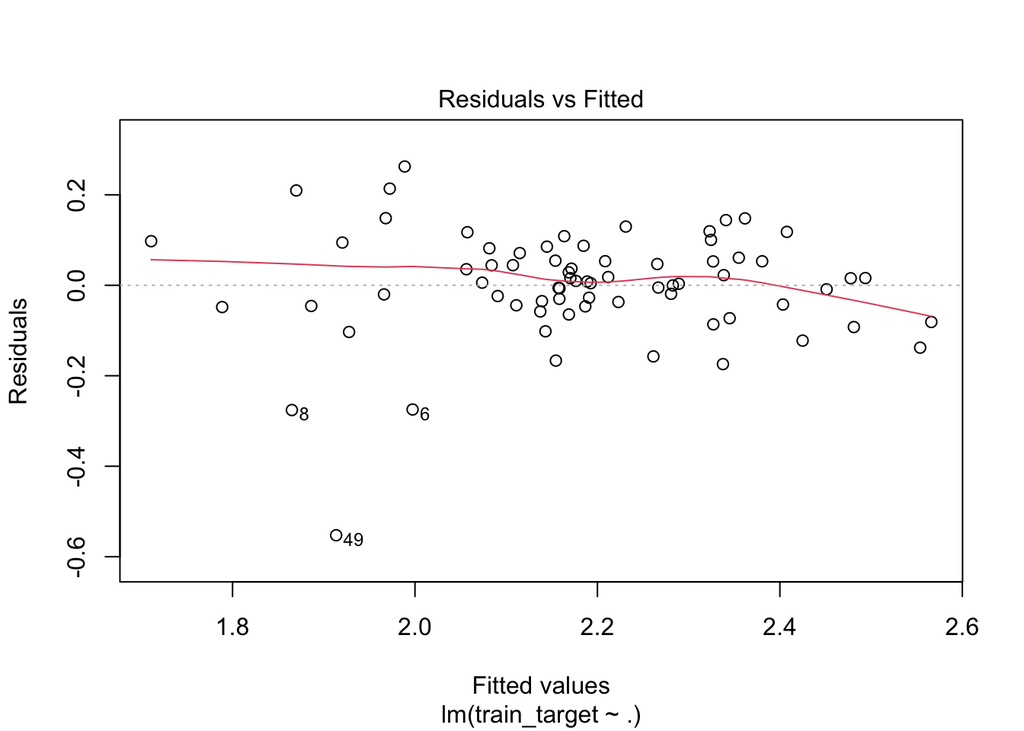

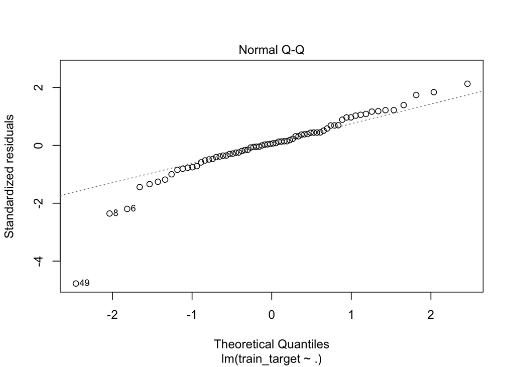

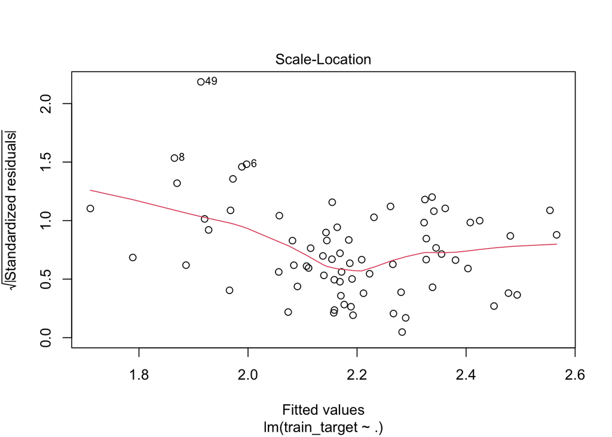

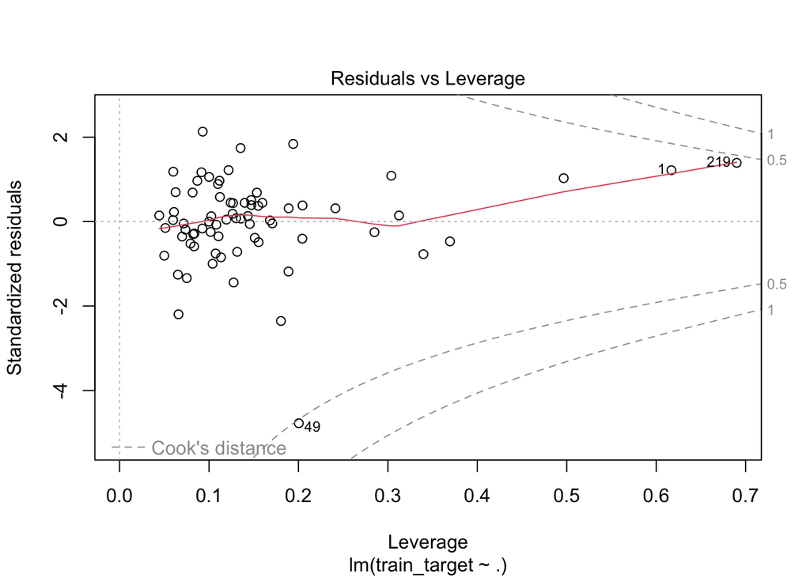

```r
plot(model)
```

Here, I trained a linear regression model using the training set. The model is then used to make predictions on the test set, and the mean squared error (MSE) between the actual test target values and the predicted values. The MSE measures the average squared difference between the predicted and actual values, and is commonly used as a metric for evaluating the performance of regression models. Since our MSE is 0.0154 which indicates better performance, as it means the model’s predictions are closer to the actual values. The plot visualizes our findings.

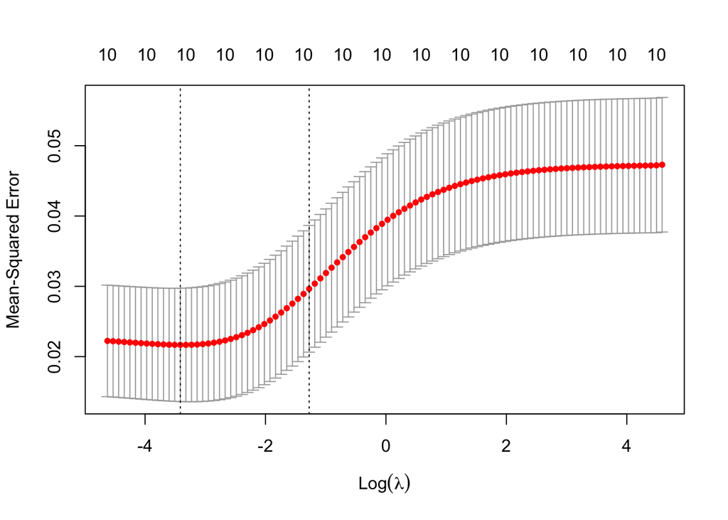

```r
x_train <- as.matrix(train_transformed)
set.seed(123)
cv_model <- cv.glmnet(x_train, train_target, alpha = 0, nfolds = 10, type.measure = "mse")
plot(cv_model)
```

```r
opt_lambda <- cv_model$lambda.min
ridge_model <- glmnet(x_train, train_target, alpha = 0, lambda = opt_lambda)
coef(ridge_model)
```

```
## 11 x 1 sparse Matrix of class "dgCMatrix"
##                        s0
## (Intercept)  2.186136e+00
## PC1          8.011492e-04
## PC2         -1.984312e-05
## PC3         -7.020213e-03
## PC4          4.333413e-03
## PC5          2.157089e-03
## PC6          1.073386e-03
## PC7          4.561621e-02
## PC8          3.683296e-02
## PC9         -1.703028e-02
## PC10         8.228283e-02
```

```r
test_pred <- predict(ridge_model, newx = as.matrix(test_transformed))
mse <- mean((test_target - test_pred)^2)
print(paste("Mean Squared Error:", mse))
```

```
## [1] "Mean Squared Error: 0.00973040658445515"
```

```r
ridge_coefs <- coef(ridge_model)
ridge_coefs_matrix <- as.matrix(ridge_coefs)
ridge_coefs_df <- as.data.frame(ridge_coefs_matrix)
colnames(ridge_coefs_df) <- c("Coefficient")
positive_coefs <- ridge_coefs_df[ridge_coefs_df$Coefficient > 0, , drop = FALSE]
print("Positive coefficients:")
```

```
## [1] "Positive coefficients:"
```

```r
print(positive_coefs)
```

```
##              Coefficient
## (Intercept) 2.1861363561
## PC1         0.0008011492
## PC4         0.0043334134
## PC5         0.0021570894
## PC6         0.0010733864
## PC7         0.0456162131
## PC8         0.0368329551
## PC10        0.0822828287
```

```r
negative_coefs <- ridge_coefs_df[ridge_coefs_df$Coefficient < 0, , drop = FALSE]
print("Negative coefficients:")
```

```
## [1] "Negative coefficients:"
```

```r
print(negative_coefs)
```

```
##       Coefficient
## PC2 -1.984312e-05
## PC3 -7.020213e-03
## PC9 -1.703028e-02
```

```r
print(paste("Mean Squared Error:", mse))
```

```
## [1] "Mean Squared Error: 0.00973040658445515"
```

Upon further discovery, ridge regression can be another model we can apply to get results. We can see that I am performing ridge regression on a training dataset. We plot our model which shows the mean squared error for different values of the regularization parameter lambda. The optimal value of lambda is found and used to fit it in the ridge regression model. Positive and Negative coefficients are separated into separate data frames for better sorting.

The testing set is then used to evaluate the model’s performance. The model is then used to make predictions on the test set using the function, and the mean squared error is calculated to evaluate the model’s performance. The ridge regression model gives us a lower MSE of 0.0097 indiciting it is a better model to use than linear regression.

```r
board_coefficients <- coef(new_model1)[grep("Board_", names(coef(new_model1)))]
most_influential_board <- names(board_coefficients)[which.max(board_coefficients)]
cat("The most influential board on improving speed is:", most_influential_board, "\n")
```

```
## The most influential board on improving speed is: Board_Type_TypePlatform
```

```r
board_type_coefficients <- coef(new_model1)[grep("Board_Type_", names(coef(new_model1)))]
most_influential_board_type <- names(board_type_coefficients)[which.max(board_type_coefficients)]
cat("The most influential board type on improving speed is:", most_influential_board_type, "\n")
```

```
## The most influential board type on improving speed is: Board_Type_TypePlatform
```

```r
grouped_by_city <- df %>% group_by(City_State)
city_avg_speed <- grouped_by_city %>% summarize(Mean_Avg_Speed = mean(Avg_Speed, na.rm = TRUE))
highest_avg_speed_city <- city_avg_speed[which.max(city_avg_speed$Mean_Avg_Speed),]
cat("The city with the highest average speed is:", highest_avg_speed_city$City_State, "with an average speed of", highest_avg_speed_city$Mean_Avg_Speed, "mph\n")
```

```
## The city with the highest average speed is: Greencastle, IN with an average speed of 10.7037 mph
```

After running different models, we had come seen that box-cox method had given us the best fitted model. But creating models after not enough. This section tells us Board_Type_TypePlatform is the most influential board on improving speed. We also now know Greencastle, IN produces the highest average speed of 10.7037 mph.

```r
pro_df1$predicted_avg_speed <- predict(new_model1, pro_df1)
mean_predicted_avg_speed_by_route <- aggregate(predicted_avg_speed ~ Route, data = pro_df1, FUN = mean)
best_route <- mean_predicted_avg_speed_by_route[which.max(mean_predicted_avg_speed_by_route$predicted_avg_speed), "Route"]
print(paste("The best route to take is Route", best_route))
```

```
## [1] "The best route to take is Route 4"
```

```r
unique_routes <- unique(df$Route)
ordered_unique_routes <- unique_routes[order(match(unique_routes, df$Route))]
route_32_name <- ordered_unique_routes[4]
print(paste("Route 4 is:", route_32_name))
```

```
## [1] "Route 4 is: ripon_west_loop"
```

From the above sections, we will find out that Route ripon_west_loop produces the best average speed on the long board.

```r
df$Is_Platform <- ifelse(df$Board_Type == "Platform", 1, 0)
logistic_model <- glm(Is_Platform ~ Board_Type, data = df, family = "binomial", control = list(maxit = 100))
summary(logistic_model)
```

```
##
## Call:
## glm(formula = Is_Platform ~ Board_Type, family = "binomial",
##     data = df, control = list(maxit = 100))
##
## Deviance Residuals:
##        Min          1Q      Median          3Q         Max
## -1.461e-06  -1.461e-06  -1.461e-06   1.461e-06   1.461e-06
##
## Coefficients:
##                          Estimate Std. Error z value Pr(>|z|)
## (Intercept)            -2.757e+01  4.910e+04  -0.001    1.000
## Board_TypeDrop Through -2.541e-12  4.181e+05   0.000    1.000
## Board_TypePlatform      5.513e+01  8.446e+04   0.001    0.999
## Board_TypeTop Mount     0.000e+00  3.425e+05   0.000    1.000
##
## (Dispersion parameter for binomial family taken to be 1)
##
##     Null deviance: 2.8041e+02  on 220  degrees of freedom
## Residual deviance: 4.7168e-10  on 217  degrees of freedom
## AIC: 8
##
## Number of Fisher Scoring iterations: 26
```

```r
set.seed(123)
trainIndex <- createDataPartition(df$Is_Platform, p = 0.8, list = FALSE, times = 1)
train_df <- df[trainIndex, ]
test_df <- df[-trainIndex, ]
logistic_model <- glm(Is_Platform ~ Board_Type, data = train_df, family = "binomial", control = list(maxit = 100))
summary(logistic_model)
```

```
##
## Call:
## glm(formula = Is_Platform ~ Board_Type, family = "binomial",
##     data = train_df, control = list(maxit = 100))
##
## Deviance Residuals:
##        Min          1Q      Median          3Q         Max
## -1.461e-06  -1.461e-06  -1.461e-06   1.461e-06   1.461e-06
##
## Coefficients:
##                          Estimate Std. Error z value Pr(>|z|)
## (Intercept)            -2.757e+01  5.475e+04  -0.001        1
## Board_TypeDrop Through  1.935e-12  4.188e+05   0.000        1
## Board_TypePlatform      5.513e+01  9.456e+04   0.001        1
## Board_TypeTop Mount     6.452e-28  4.188e+05   0.000        1
##
## (Dispersion parameter for binomial family taken to be 1)
##
##     Null deviance: 2.2391e+02  on 176  degrees of freedom
## Residual deviance: 3.7777e-10  on 173  degrees of freedom
## AIC: 8
##
## Number of Fisher Scoring iterations: 26
```

```r
predicted_probabilities <- predict(logistic_model, newdata = test_df, type = "response")
predicted_classes <- ifelse(predicted_probabilities > 0.5, 1, 0)
confusion_matrix <- confusionMatrix(table(predicted_classes, test_df$Is_Platform))
print(confusion_matrix)
```

```
## Confusion Matrix and Statistics
##
##
## predicted_classes  0  1
##                 0 29  0
##                 1  0 15
##
##                Accuracy : 1
##                  95% CI : (0.9196, 1)
##     No Information Rate : 0.6591
##     P-Value [Acc > NIR] : 1.08e-08
##
##                   Kappa : 1
##
##  Mcnemar's Test P-Value : NA
##
##             Sensitivity : 1.0000
##             Specificity : 1.0000
##          Pos Pred Value : 1.0000
##          Neg Pred Value : 1.0000
##              Prevalence : 0.6591
##          Detection Rate : 0.6591
##    Detection Prevalence : 0.6591
##       Balanced Accuracy : 1.0000
##
##        'Positive' Class : 0
##
```

```r
accuracy <- confusion_matrix$overall["Accuracy"]
sensitivity <- confusion_matrix$byClass["Sensitivity"]
specificity <- confusion_matrix$byClass["Specificity"]
cat("Accuracy: ", accuracy, "\n")
```

```
## Accuracy:  1
```

```r
cat("Sensitivity: ", sensitivity, "\n")
```

```
## Sensitivity:  1
```

```r
cat("Specificity: ", specificity, "\n")
```

```
## Specificity:  1
```

The logistic regression model perfectly classifies the Is_platform response variable. With the model achieving the accuracy score of 1, it correctly predicts all the observations in the test dataset. Since same information is used to predict target variable we achieve the accuract score of 1. This tell us that our model is correctly working from what it has learned.

CONCLUSION

Additionally, we explored more with the dataset and performed ridge regression with cross-validation to find the optimal lambda value, and principal component analysis (PCA) was used to reduce the dimensionality of the data. We also applied a logistic regression model, which perfectly classified the Is_platform response variable. With the model achieving an accuracy score of 1, it correctly predicted all the observations in the test dataset. Since the same information is used to predict the target variable, we achieved an accuracy score of 1. This indicates that our model is working correctly based on what it has learned.

Finally, a linear regression model was trained on the transformed data, and the mean squared error (MSE) was calculated for model evaluation to determine the accuracy of the model’s predictions. Overall, our analysis provides valuable insights into the factors that influence the speed of longboard rides, and our findings could be used to inform future research in this area.